# Master Regulator Analysis with RTN package

Pablo L. Cardozo

2024-07-04

This document describes the main coding steps used in this work to perform Master Regulator Analysis using the RTN package.

### Loading required libraries

```r
# LOADING REQUIRED LIBRARIES
libs <- c('dplyr', 'ggplot2', 'plotly', "tools", "reshape2", "ggrepel",
          'statmod', 'Hmisc', 'biomaRt', 'AnnotationDbi', 'org.Hs.eg.db', 'forcats',
          'ggstance','stringr', 'ggprism', 'viridis', 'igraph', 'ggraph',
          'ComplexHeatmap', 'circlize', 'edgeR','matrixStats', 'cowplot',
          'graphlayouts', 'ggforce', 'dbplyr', 'ggnewscale', 'ggrepel',
          "rhdf5", "preprocessCore", "sva", 'RTN', "RTNduals", 'genefilter',
          'clusterProfiler', 'DESeq2', 'edgeR', 'reshape2', 'VennDiagram',
          'RColorBrewer','svMisc', 'tibble', 'tidyverse', 'shadowtext')

for (i in libs){
  if (!is.element(i, installed.packages()[,1])){
    BiocManager::install(i, force = T)}

  library(i, character.only = T, quietly = T, warn.conflicts = F)

}
```

### Downloading microglia transcriptomic data from ARCHS4

In this step, human microglia transcriptomic data is downloaded from ARCHS4 database and prepared for later co-expression network reconstruction using the human transcription factors as centroids.

```r
setwd(/PATH/)

options(timeout = Inf)
destination_file = "human_gene_v2.2.h5"
extracted_expression_file = "microglia_expression_matrix.tsv"
url = "https://s3.dev.maayanlab.cloud/archs4/files/human_gene_v2.2.h5"

# Check if gene expression file was already downloaded, if not in current directory download file from repository
if(!file.exists(destination_file)){
    print("Downloading compressed gene expression matrix.")
    download.file(url, destination_file, quiet = FALSE, mode = 'wb')
}

# Selected samples to be downloaded
samp = c("GSM1560614","GSM1560855","GSM1560800","GSM1560627","GSM1560788","GSM1560814","GSM1560622","GSM1560712","GSM2285366","GSM1560775","GSM1560630","GSM1560727","GSM1560782","GSM1560749","GSM1560680","GSM1560721","GSM1560831","GSM1560592","GSM1560866","GSM1560580","GSM1560827","GSM1560668","GSM1560640","GSM1560706","GSM1560736","GSM1560635","GSM1560703","GSM1560799","GSM1560792","GSM1560681","GSM1560694",
"GSM1560657","GSM1560683","GSM1560700","GSM1560743","GSM1560602","GSM1560835","GSM1560642","GSM1560625","GSM2285362","GSM1560758","GSM1560634","GSM1560702","GSM1560605","GSM1560809","GSM1560663","GSM1560629","GSM1560823","GSM1560581","GSM1560741","GSM1560852","GSM1560667","GSM1560750","GSM1560811","GSM1560808","GSM1560724","GSM2285371","GSM1560686","GSM1560665","GSM1560662","GSM1560821",
"GSM1560654","GSM1560607","GSM1560790","GSM1560753","GSM1560740","GSM1560757","GSM1560829","GSM1560812","GSM1560861","GSM1560641","GSM1560608","GSM1560828","GSM1560658","GSM1560664","GSM1560713","GSM1560764","GSM1560656","GSM1560784","GSM1560723","GSM1560659","GSM1560769","GSM1560583","GSM1560678","GSM1560619","GSM1560837","GSM1560735","GSM1560845","GSM1560726","GSM1560760","GSM1560785",
"GSM1560728","GSM1560704","GSM1560839","GSM1560864","GSM1560751","GSM1560717","GSM1560673","GSM1560584","GSM1560690","GSM1560698","GSM2285369","GSM1560600","GSM1560708","GSM1560794","GSM1560776","GSM1560597","GSM1560772","GSM1560626","GSM1560648","GSM1560836","GSM1560838","GSM1560672","GSM1560691","GSM1560830","GSM1560797","GSM1560620","GSM1560679","GSM1560582","GSM1560771","GSM1560588",
"GSM1560789","GSM1560666","GSM1560798","GSM2285363","GSM1560731","GSM1560744","GSM1560603","GSM1560671","GSM1560722","GSM1560770","GSM1560857","GSM1560637","GSM1560833","GSM1560616","GSM1560593","GSM1560590","GSM1560767","GSM1560714","GSM1560825","GSM1560738","GSM1560643","GSM1560819","GSM2285368","GSM1560843","GSM1560669","GSM1560746","GSM1560801","GSM1560710","GSM2285364","GSM1560773",
"GSM1560585","GSM2285367","GSM1560795","GSM1560820","GSM1560599","GSM1560587","GSM1560766","GSM1560796","GSM1560793","GSM1560778","GSM1560594","GSM1560615","GSM1560824","GSM1560752","GSM1560858","GSM1560725","GSM1560817","GSM1560613","GSM1560651","GSM1560677","GSM1560834","GSM1560720","GSM1560754","GSM1560623","GSM1560601","GSM1560610","GSM1560688","GSM1560660","GSM1560578","GSM1560867",
"GSM1560591","GSM1560853","GSM1560595","GSM1560807","GSM1560598","GSM1560612","GSM1560596","GSM1560791","GSM1560604","GSM1560815","GSM1560755","GSM1560762","GSM1560734","GSM1560780","GSM1560842","GSM1560617","GSM1560692","GSM1560705","GSM1560632","GSM1560850","GSM1560865","GSM1560844","GSM1560781","GSM1560606","GSM1560639","GSM1560849","GSM1560687","GSM1560579","GSM1560739","GSM1560685",
"GSM1560747","GSM1560826","GSM1560732","GSM1560854","GSM1560586","GSM1560624","GSM1560860","GSM1560661","GSM1560806","GSM1560589","GSM2285370","GSM2285372","GSM1560756","GSM1560649","GSM1560868","GSM1560777","GSM1560674","GSM1560621","GSM1560695","GSM1560718","GSM1560804","GSM1560847","GSM1560682","GSM1560684","GSM1560805","GSM1560618","GSM1560730","GSM1560611","GSM1560711","GSM1560650",
"GSM1560848","GSM2285365","GSM1560716","GSM1560813","GSM1560803","GSM1560787","GSM1560715","GSM1560742","GSM1560636","GSM1560846","GSM1560707","GSM1560655","GSM1560733","GSM1560851","GSM1560748","GSM1560675","GSM1560802","GSM1560765","GSM1560816","GSM1560644","GSM1560633","GSM1560759","GSM1560818","GSM1560841","GSM1560653","GSM1560783","GSM1560670","GSM1560697","GSM1560652","GSM1560779",
"GSM1560761","GSM1560786","GSM1560863","GSM2285373","GSM1560810","GSM1560628","GSM1560763","GSM1560647","GSM1560856","GSM1560699","GSM1560696","GSM1560737","GSM1560768","GSM1560609","GSM1560869","GSM1560676","GSM1560631","GSM1560729","GSM1560745","GSM1560638","GSM1560859","GSM1560774","GSM1560646","GSM1560701","GSM1560862","GSM1560709","GSM1560689","GSM1560840","GSM1560822","GSM1560832",
"GSM1560693","GSM1560719","GSM1560645","GSM2360257","GSM2360287","GSM2360252","GSM2360253","GSM2360276","GSM2551704","GSM2360254","GSM2551705","GSM2360275","GSM2551706","GSM2445480","GSM2360284","GSM2360255","GSM2360278","GSM2360279","GSM2360285","GSM2360277","GSM2360288","GSM2360256","GSM2445478","GSM2445479","GSM2360283","GSM2360286","GSM2360274","GSM2576766","GSM2576771","GSM2576767",
"GSM2576761","GSM2576757","GSM2576772","GSM2576758","GSM2576765","GSM2576769","GSM2576764","GSM2576770","GSM2576768","GSM2576759","GSM2576762","GSM2464315","GSM2464316","GSM3019392","GSM3019393","GSM3019394","GSM3019397","GSM3019398","GSM3019399","GSM3081106","GSM3081107","GSM3081108","GSM3081109","GSM3081110","GSM3081111","GSM3081112","GSM3081113","GSM3081114","GSM3081115","GSM3081116",
"GSM3081117","GSM3081118","GSM3081119","GSM3081120","GSM3081121","GSM3081122","GSM3081123","GSM3081124","GSM3081125","GSM3081126","GSM3081127","GSM3081128","GSM3081129","GSM3081130","GSM3081131","GSM3081132","GSM3081133","GSM3081134","GSM3081135","GSM3081136","GSM3081137","GSM3081138","GSM3081139","GSM3081140","GSM3081141","GSM3081142","GSM3081143","GSM3081144","GSM2751149","GSM2751150",
"GSM2751151","GSM2751152","GSM2751153","GSM2751154","GSM2751155","GSM2751156","GSM2734882","GSM2734883","GSM2734884","GSM2734885","GSM2734886","GSM2734887","GSM2734888","GSM2734889","GSM2734890","GSM3045818","GSM3045819","GSM3045820","GSM3045821","GSM3045822","GSM3045823","GSM3045824","GSM3045825","GSM3045826","GSM3045827","GSM3045828","GSM3045829","GSM3045830","GSM3045831","GSM3045832",
"GSM3045833","GSM3045834","GSM3045835","GSM3045836","GSM3045837","GSM3045838","GSM3045839","GSM3045840","GSM3045841","GSM3045842","GSM3045843","GSM3045844","GSM3045845","GSM3045846","GSM3045847","GSM3045848","GSM4026496","GSM4026497","GSM4026498","GSM4026499","GSM4026500","GSM4026501","GSM4026502","GSM4026503","GSM4026504","GSM4026505","GSM4026506","GSM4026507","GSM3908536","GSM3908537",
"GSM3908538","GSM3908539","GSM3908540","GSM3908541","GSM3908542","GSM3908543","GSM3908544","GSM3908545","GSM3908546","GSM3908547","GSM3908548","GSM3908549","GSM3908550","GSM3908551","GSM3908552","GSM3908553","GSM3908554","GSM3908555","GSM3908556","GSM3908557","GSM3908558","GSM3908559","GSM3908560","GSM3908561","GSM3908568","GSM3908569","GSM3908570","GSM3908571","GSM4133389","GSM4133390",
"GSM4133391","GSM4133392","GSM4133393","GSM4133394","GSM4133407","GSM4133408","GSM4133409","GSM4133410","GSM4133411","GSM4133412","GSM4133413","GSM4133414","GSM4133415","GSM4133416","GSM4133417","GSM4133418","GSM4133423","GSM4133424","GSM4214857","GSM4214858","GSM4214859","GSM4214860","GSM4214864","GSM4214865","GSM4214866","GSM4214867","GSM4214868","GSM4214869","GSM4214870","GSM5175994",
"GSM4214871","GSM4214872","GSM4214873","GSM4214874","GSM4214875","GSM4214876","GSM4214877","GSM4214879","GSM4214880","GSM4214881","GSM4214882","GSM4214883","GSM4214884","GSM4214885","GSM4214886","GSM4214887","GSM4214888","GSM4214889","GSM4214890","GSM4214891","GSM4214892","GSM4214893","GSM4214894","GSM4214895","GSM4214896","GSM4214897","GSM4214898","GSM4214899","GSM4214900","GSM4214901",
"GSM4214902","GSM4214903","GSM4214904","GSM4214905","GSM4214906","GSM4214907","GSM4214908","GSM4214909","GSM4214910","GSM4214911","GSM4214912","GSM4214913","GSM4214914","GSM4214915","GSM4214916","GSM4214917","GSM4214918","GSM4214919","GSM4214921","GSM4214922","GSM4214923","GSM4214924","GSM4214925","GSM4214926","GSM4214927","GSM4214928","GSM4214929","GSM4214931","GSM4214932","GSM4214933",
"GSM4214935","GSM4214936","GSM4214937","GSM4214938","GSM4214939","GSM4214941","GSM4214942","GSM4214943","GSM4214944","GSM4214945","GSM4214946","GSM4214947","GSM4214948","GSM4214949","GSM4214951","GSM4214952","GSM4214953","GSM4214954","GSM4214955","GSM4214956","GSM4214957","GSM4214958","GSM4214959","GSM4214960","GSM4214961","GSM4214962","GSM4214963","GSM4214964","GSM4214965","GSM4214966",
"GSM4214967","GSM4214968","GSM4214969","GSM4214970","GSM4214971","GSM4214972","GSM4214973","GSM4214974","GSM4214975","GSM4214976","GSM4214977","GSM4214978","GSM4214979","GSM4214980","GSM4214981","GSM4214982","GSM4214983","GSM4214984","GSM4214985","GSM4214986","GSM4214987","GSM4214988","GSM4214989","GSM4214990","GSM4214991","GSM4214992","GSM4214993","GSM4214994","GSM4214995","GSM4214996",
"GSM4214998","GSM4214999","GSM4215000","GSM4215001","GSM4215002","GSM4215003","GSM4215004","GSM4215005","GSM4215006","GSM4215008","GSM4215009","GSM4215010","GSM4215011","GSM4215012","GSM4215013","GSM4215014","GSM4215015","GSM4215016","GSM4215017","GSM4215018","GSM4215019","GSM4215020","GSM4215021","GSM4215022","GSM4215023","GSM4215024","GSM4215025","GSM4215026","GSM4215027","GSM4215028",
"GSM4215029","GSM4215030","GSM4215032","GSM4215033","GSM4215034","GSM4215036","GSM4215037","GSM4215038","GSM4215039","GSM4215040","GSM4215041","GSM4215042","GSM4215043","GSM4215044","GSM4215045","GSM4215046","GSM4215047","GSM4215048","GSM4215049","GSM4215050","GSM4215051","GSM4215052","GSM4215053","GSM4215054","GSM4215055","GSM4215056","GSM4215057","GSM4215058","GSM4215059","GSM4215060",
"GSM4215061","GSM4215062","GSM4215063","GSM4215064","GSM4215065","GSM4215066","GSM4215067","GSM4215068","GSM4215069","GSM4215070","GSM4215071","GSM4215072","GSM4215073","GSM4215075","GSM4215076","GSM4215078","GSM4215079","GSM4215080","GSM4215081","GSM4215082","GSM4215083","GSM4215086","GSM4215087","GSM4215088","GSM4215089","GSM4215090","GSM4215091","GSM4215092","GSM4215093","GSM4280639",
"GSM4280640","GSM4280641","GSM4280642","GSM4280643","GSM4280644","GSM4280645","GSM4280646","GSM4280647","GSM4280648","GSM4280649","GSM4280650","GSM4280651","GSM4280652","GSM4648885","GSM4648886","GSM4648887","GSM4648888","GSM4648889","GSM4648890","GSM4648891","GSM4648892","GSM4648893","GSM4648894","GSM4648895","GSM4648896","GSM4648897","GSM4648899","GSM4648900","GSM4648901","GSM4648902",
"GSM4648903","GSM4648904","GSM4648905","GSM4648906","GSM4648907","GSM4648908","GSM4648909","GSM4648910","GSM4648911","GSM4648912","GSM4648913","GSM4648914","GSM4648915","GSM4648916","GSM4648917","GSM4648918","GSM4648919","GSM4648920","GSM4648921","GSM4648922","GSM4648923","GSM4648924","GSM3583751","GSM3583752","GSM3583753","GSM3583754","GSM3583755","GSM3583756","GSM3583757","GSM3583758",
"GSM3583759","GSM3583760","GSM3583761","GSM3583762","GSM3583764","GSM3717626","GSM3717627","GSM3717628","GSM3717629","GSM3717630","GSM3717631","GSM3717633","GSM3717634","GSM3717635","GSM3717636","GSM4065828","GSM4065829","GSM4065830","GSM4065831","GSM4065832","GSM4065833","GSM4065834","GSM4065835","GSM4143592","GSM4143593","GSM4143594","GSM4143595","GSM4214934","GSM4215031","GSM4215077",
"GSM4648898","GSM4795671","GSM4795672","GSM4795673","GSM4795674","GSM4801316","GSM4801317","GSM4801318","GSM4801319","GSM4801320","GSM4801321","GSM4801322","GSM4801323","GSM4801324","GSM4801325","GSM4801326","GSM4801327","GSM4801328","GSM4801329","GSM4801330","GSM4801331","GSM4801332","GSM4801333","GSM2334836","GSM2334838","GSM2334840","GSM4977135","GSM4988829","GSM4988830","GSM5491626",
"GSM4988831","GSM4988832","GSM4988833","GSM4988834","GSM4988835","GSM4988836","GSM4988837","GSM4988838","GSM4988839","GSM4988840","GSM4988841","GSM4988842","GSM4988843","GSM4988844","GSM4988845","GSM4988846","GSM4988847","GSM4988848","GSM4988849","GSM4988850","GSM4988851","GSM4988852","GSM4994452","GSM4994453","GSM4994454","GSM4994456","GSM5006260","GSM5006261","GSM5006262","GSM5175993")
```

```r
# Retrieve information from compressed data
samples = h5read(destination_file, "meta/samples/geo_accession")
genes = h5read(destination_file, "meta/genes/ensembl_gene_id")
series = h5read(destination_file, 'meta/samples/series_id')

# Identify columns to be extracted
sample_locations = which(samples %in% samp)

# extract gene expression from compressed data
expression = t(h5read(destination_file, "data/expression", index=list(sample_locations, 1:length(genes))))
H5close()
rownames(expression) = genes
colnames(expression) = samples[sample_locations]
series <- series[sample_locations]
batchid = match(series, unique(series))

# Remove low count genes
keep <- filterByExpr(expression, group = batchid)
expression <- expression[keep,]

# normalize samples and correct for differences in gene count distribution
correctedExpression <- ComBat_seq(expression, batchid, full_mod = F)
correctedExpression <- vst(correctedExpression)

# Print file
write.table(correctedExpression, file=extracted_expression_file, sep="\t", quote=FALSE, col.names=NA)
print(paste0("Expression file was created at ", getwd(), "/", extracted_expression_file))

# Creating data frame with gene annotations for network reconstruction

gene_annot <- as.data.frame(rownames(correctedExpression))
colnames(gene_annot) <- 'ENSEMBL'

db_homo_s <- useMart(biomart = 'ENSEMBL_MART_ENSEMBL', dataset = 'hsapiens_gene_ensembl')

dictionary <- getBM(attributes = c('ensembl_gene_id', 'hgnc_symbol', 'entrezgene_id'),
                    filters = 'ensembl_gene_id', values = gene_annot$ENSEMBL,
                    mart = db_homo_s, uniqueRows = F, useCache = T)

gene_annot <- left_join(gene_annot, dictionary, by = join_by('ENSEMBL' == 'ensembl_gene_id'),
                        multiple = 'first') %>% relocate(c(hgnc_symbol, entrezgene_id), .after = ENSEMBL)


gene_annot <- gene_annot[!is.na(gene_annot$hgnc_symbol),]
gene_annot <- gene_annot[gene_annot$hgnc_symbol != '',]

colnames(gene_annot) <- c('ENSEMBL', 'SYMBOL', 'ENTREZ')

write.table(gene_annot, file = 'gene_annotation.txt', quote = F, sep = '\t')
```

### Reconstructing co-expression network around transcription factors

The RTN package is used to reconstruct co-expression networks around the human transcription factors. In that way, each transcription factor will comprise a regulon, that is, a group of genes that are regulated together by a given driver (in this case, a transcription factor).

This step requires a huge amount of memory and processing power. So, it is strongly suggested to be run in a dedicated server.

```r
# Importing TFs list to be used as regulons
tfs <-read.table('DatabaseExtract_v2.0.txt', sep = '\t', quote = '', header = T)
tfs <- tfs[tfs$isTF == 'Yes',]
tfs <- unique(c(tfs$Ensembl.ID))

# Importing normalized gene-level counts from RUV-seq normalized data
cardozo_data <- read.table(file = 'normCounts_RUV.csv', header = T, sep = '\t',
                           row.names = 1)

cardozo_data = vst(as.matrix(cardozo_data))

microglia_exp_matrix <- as.matrix(subset(correctedExpression, rownames(correctedExpression) %in% rownames(cardozo_data)))
microglia_exp_matrix <- subset(microglia_exp_matrix, rownames(microglia_exp_matrix) %in% gene_annot$ENSEMBL)

tfs <- tfs[which(tfs %in% rownames(microglia_exp_matrix))]

microglia_tni <- tni.constructor(expData = microglia_exp_matrix,
                                 regulatoryElements = tfs,
                                 rowAnnotation = gene_annot)

options(cluster = snow::makeCluster(spec = 20, 'SOCK'))

microglia_tni <- tni.permutation(microglia_tni, pValueCutoff = 3e-7)
microglia_tni <- tni.bootstrap(microglia_tni)
microglia_tni <- tni.dpi.filter(microglia_tni, eps = 0.05, minRegulonSize = 15)

stopCluster(getOption("cluster"))

microglia_tni <- tni.gsea2(microglia_tni, minRegulonSize = 15)
```

### Master Regulator Analysis

After network reconstruction, master regulon analysis was carried out as described in the RTN package vignette. Files generated in [DEG analysis using EdgeR](https://github.com/plcardozo/Cardozo-et-al---iMG-transcriptomics/blob/main/DEG-Analysis-with-EdgeR.html) are also required in this step.

```r
# Retrieve phenotype and hits files created in DEG analysis

phenotype <- readRDS('numeric_named_DEGs.rds')
hits <- readRDS('hits_DEGs.rds')

# MRA for HCP_tnf vs HCP_ns
mra_hthn <- tni2tna.preprocess(object = microglia_tni, phenotype = phenotype$num_deg_hthn,
                               hits = hits$hits_deg_hthn)
mra_hthn <- tna.mra(mra_hthn, minRegulonSize = 15, tfs = tfs)

mra_hthn_res <- tna.get(mra_hthn, what = 'mra', ntop = -1, idkey = 'SYMBOL')
mra_hthn_res <- mra_hthn_res[mra_hthn_res$Adjusted.Pvalue < 0.05,]

mra_hthn_gsea <- tna.gsea2(mra_hthn, minRegulonSize = 15, sizeFilterMethod = 'posORneg', tnet = 'dpi', signature = c('phenotype', 'hits'))
mra_hthn_gsea <- tna.get(mra_hthn_gsea, what = 'gsea2', ntop = -1)
mra_hthn_gsea <- mra_hthn_gsea$differential
mra_hthn_gsea <- subset(mra_hthn_gsea, mra_hthn_gsea$Regulon %in% mra_hthn_res$Regulon)
write.table(mra_hthn_gsea, file = 'mra_vs_HCP_tnf.csv', quote = F, sep = '\t')

# MRA for SCZ_ns vs HCP_ns
mra_snhn <- tni2tna.preprocess(object = microglia_tni, phenotype = phenotype$num_deg_snhn,
                               hits = hits$hits_deg_snhn)

mra_snhn <- tna.mra(mra_snhn, minRegulonSize = 15, tfs = tfs)

mra_snhn_res <- tna.get(mra_snhn, what = 'mra', ntop = -1, idkey = 'SYMBOL')
mra_snhn_res <- mra_snhn_res[mra_snhn_res$Adjusted.Pvalue < 0.05,]

mra_snhn_gsea <- tna.gsea2(mra_snhn, minRegulonSize = 15, sizeFilterMethod = 'posORneg', tnet = 'dpi', signature = c('phenotype', 'hits'))
mra_snhn_gsea <- tna.get(mra_snhn_gsea, what = 'gsea2', ntop = -1)
mra_snhn_gsea <- mra_snhn_gsea$differential
mra_snhn_gsea <- subset(mra_snhn_gsea, mra_snhn_gsea$Regulon %in% mra_snhn_res$Regulon)
write.table(mra_snhn_gsea, file = 'mra_vs_SCZ_ns.csv', quote = F, sep = '\t')

# MRA for SCZ_tnf vs HCP_ns
mra_sthn <- tni2tna.preprocess(object = microglia_tni, phenotype = phenotype$num_deg_sthn,
                               hits = hits$hits_deg_sthn)

mra_sthn <- tna.mra(mra_sthn, minRegulonSize = 15, tfs = tfs)

mra_sthn_res <- tna.get(mra_sthn, what = 'mra', ntop = -1, idkey = 'SYMBOL')
mra_sthn_res <- mra_sthn_res[mra_sthn_res$Adjusted.Pvalue < 0.05,]

mra_sthn_gsea <- tna.gsea2(mra_sthn, minRegulonSize = 15, sizeFilterMethod = 'posORneg', tnet = 'dpi', signature = c('phenotype', 'hits'))
mra_sthn_gsea <- tna.get(mra_sthn_gsea, what = 'gsea2', ntop = -1)
mra_sthn_gsea <- mra_sthn_gsea$differential
mra_sthn_gsea <- subset(mra_sthn_gsea, mra_sthn_gsea$Regulon %in% mra_sthn_res$Regulon)
write.table(mra_sthn_gsea, file = 'mra_vs_SCZ_tnf.csv', quote = F, sep = '\t')
```

### Venn Diagram plot to show overlapping regulons per group

```r
list_venn <- list(c(mra_hthn_gsea$Regulon), c(mra_snhn_gsea$Regulon),
                  c(mra_sthn_gsea$Regulon))

venn_diagram_mra <- venn.diagram(x = list_venn,
                                 filename = 'Venn Diagram MRAs.tiff',
                                 category.names = c('vs_HCP_tnf', 'vs_SCZ_ns', 'vs_SCZ_tnf'),
                                 output = F, lwd = 1, col = 'black', cat.cex = 0.2, cex = 1,
                                 fill = viridis(3, alpha = 0.3, option = 'viridis'), fontfamily = 'sans',
                                 cat.fontfamily = "sans", euler.d = F, scaled = F,
                                 disable.logging = T, height = 1500, width = 1500)
```

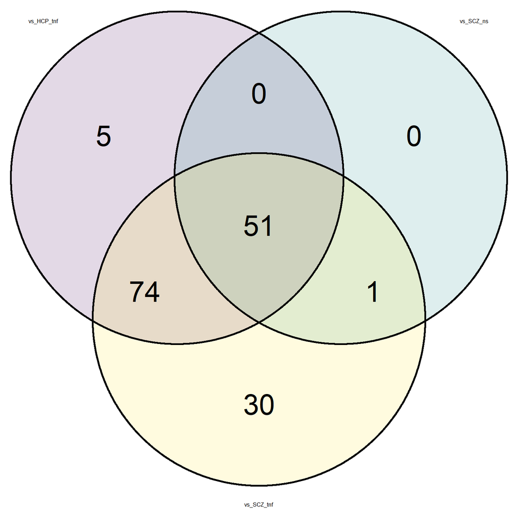

Example of Venn Diagram

### Bar plots to indicate MRA regulon activity per group

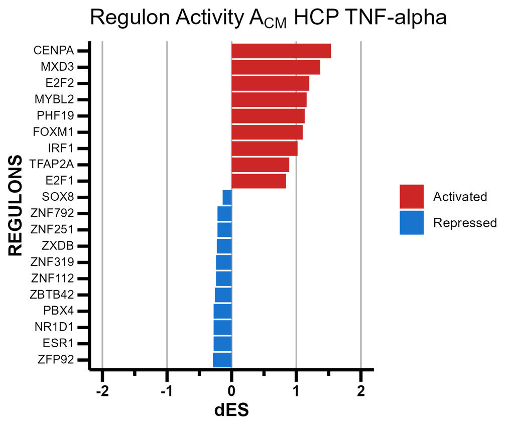

Example of Bar plot of MRA results per group

```r
# HCP TNF

box_hthn_gsea <- subset(mra_hthn_gsea, mra_hthn_gsea$Adjusted.Pvalue < 0.1)
box_hthn_gsea <- box_hthn_gsea[order(-box_hthn_gsea$Observed.Score),]
box_hthn_gsea <- rbind(head(box_hthn_gsea, 10), tail(box_hthn_gsea,10))
box_hthn_gsea$Activity <- ifelse(box_hthn_gsea$Observed.Score > 0, 'Activated', 'Repressed')

barplot_ht <- ggplot(box_hthn_gsea, aes(x = Observed.Score, y = reorder(Regulon, Observed.Score), fill = Activity)) +
  theme_classic() + geom_bar(stat = 'identity', position = 'dodge') +
  ggtitle(expression('Regulon Activity A'['CM']*' HCP TNF-alpha')) +
  scale_x_continuous(limits = c(-2,2), breaks = seq(-2,2, 1.0), guide = 'prism_minor') +
  xlab('dES') + ylab('REGULONS') + scale_fill_manual(values = c('firebrick3', 'dodgerblue3')) +
  theme(axis.text.x = element_text(family = 'sans', face = 'bold', size = 10, color = 'black'),
        axis.text.y = element_text(family = 'sans', face = 'plain', size = 8, color = 'black', vjust = 0.4),
        title = element_text(family = 'sans', face = 'bold', size = 12, hjust = 0.5),
        axis.ticks = element_line(color = 'black', linewidth = 1),
        axis.line = element_line(color = 'black', linewidth = 1),
        panel.grid.major.x = element_line(color = 'grey70', linewidth = 0.5),
        legend.title = element_blank(),
        axis.ticks.length = unit(8, "pt"), prism.ticks.length = unit(4, "pt"))

ggsave('Barplot top and bottom 10 regulons ACM HCP TNF.tiff', plot = barplot_ht,
       width = 120, height = 100, unit = 'mm', compression = 'lzw')
```

### Overlap between genes regulated by each regulon and the WGCNA modules

To carry out this analysis, we imported the genes list from each WGCNA module obtained in our [WGCNA analysis](https://github.com/plcardozo/Cardozo-et-al---iMG-transcriptomics/blob/main/WGCNA_PabloCollab_v2.html) and, then, used the *tni.overlap.genesets* function from the RTN package.

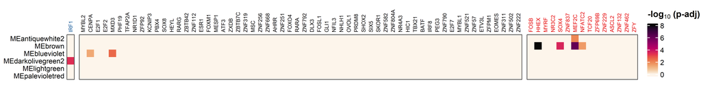

Example of Heatmap for Regulons vs WGCNA modules

```r
# Filtering only activated or repressed regulons found in each group

hcp_tnf_sig_mra <- mra_hthn_gsea$Regulon[mra_hthn_gsea$Adjusted.Pvalue < 0.1]
scz_tnf_sig_mra <- mra_sthn_gsea$Regulon[mra_sthn_gsea$Adjusted.Pvalue < 0.1]
scz_ns_sig_mra <- mra_snhn_gsea$Regulon[mra_snhn_gsea$Adjusted.Pvalue < 0.1]

sig_mra <- unique(c(hcp_tnf_sig_mra, scz_ns_sig_mra, scz_tnf_sig_mra))

# Importing WGCNA modules and their associated genes

modules <- read.table(file = 'WGCNA_Modules_Gene.txt', header = T, sep = '\t')
modules[is.na(modules)] <- ''
modules <- stack(modules)
modules <- modules %>% relocate(ind, .before = values)
modules <- modules[modules$values != '',]
modules <- deframe(modules)
modules <- split(unname(modules), names(modules))

# Running overlap between regulon target genes and WGCNA modules

modules_overlap <- t(as.matrix(as.data.frame(tni.overlap.genesets(microglia_tni, modules[c('MEantiquewhite2', 'MEbrown', 'MEblueviolet', 'MEdarkolivegreen2', 'MElightgreen', 'MEpalevioletred')], regulatoryElements = sig_mra,
                                                                  minSetSize = 15, method = 'HT', pValueCutoff = 0.05, sizeFilterMethod = 'posORneg'))))

# Preparing data for heatmap plot

modules_cluster <- matrix(data = 0, nrow = 6, ncol = length(sig_mra))
rownames(modules_cluster) <- c('MEantiquewhite2', 'MEbrown', 'MEblueviolet', 'MEdarkolivegreen2', 'MElightgreen', 'MEpalevioletred')
colnames(modules_cluster) <- c(sig_mra)

for (i in 1:ncol(modules_overlap)){
  a_module <- modules_overlap[1,i]
  a_regulon <- modules_overlap[2,i]

  modules_cluster[a_module, a_regulon] <- -log10(as.numeric(modules_overlap[9,i]))
}
rm(i, a_module, a_regulon)

matrix_reg_cluster <- data.frame(regulons = colnames(modules_cluster))
matrix_reg_cluster$cluster <- NA
matrix_reg_cluster$cluster[matrix_reg_cluster$regulons %in% setdiff(hcp_tnf_sig_mra, c(mra_snhn_gsea$Regulon, mra_sthn_gsea$Regulon))] <- 'hcp_tnf'
matrix_reg_cluster$cluster[matrix_reg_cluster$regulons %in% setdiff(scz_tnf_sig_mra, c(mra_hthn_gsea$Regulon, mra_snhn_gsea$Regulon))] <- 'scz_tnf'
matrix_reg_cluster$cluster[is.na(matrix_reg_cluster$cluster)] <- 'same'
rownames(matrix_reg_cluster) <- matrix_reg_cluster$regulons
matrix_reg_cluster <- subset(matrix_reg_cluster, select = 2)

col_cluster <- factor(c(matrix_reg_cluster$cluster), levels = c('hcp_tnf', 'same', 'scz_tnf'))

heatmap2modules <- Heatmap(modules_cluster, col = colorRamp2(seq(0,ceiling(max(modules_cluster)),2), hcl_palette = 'Rocket', reverse = T), border = 'grey30',
                           name = '-log10 p-adj', column_split = col_cluster, row_names_centered = F, column_dend_reorder = T,
                           column_names_side = 'top', column_names_centered = F, cluster_rows = F, cluster_columns = F,
                           show_column_dend = F, show_row_dend = F, row_names_side = 'left', row_gap = unit(2, 'mm'), column_gap = unit(2, 'mm'),
                           show_column_names = T, cluster_column_slices = F, cluster_row_slices = F, column_title = NULL, row_title = NULL,
                           row_names_gp = gpar(fontfamily = 'sans', fontsize = 8),
                           width = ncol(modules_cluster) * unit(3, 'mm'), height = nrow(modules_cluster) * unit(3, 'mm'),
                           column_names_gp = gpar(col = c('#0b5394', 'black', '#e50000'), fontfamily = 'sans', fontsize = 6),
                           heatmap_legend_param = list(title = expression(bold('-log'[10]*' (p-adj)')), grid_height = unit(8, 'mm'), grid_width = unit(4, 'mm'), labels_gp = gpar(family = 'sans', fontsize = 8),
                                                       title_gp = gpar(fontfamily = 'sans', fontsize = 10, fontface = 'bold'), at = seq(0,ceiling(max(modules_cluster)),2),
                                                       title_position = 'topleft'))

tiff('Heatmap Overlap WGCNA Modules and Regulons.tiff', units = 'mm', res = 600, width = 280, height = 35, compression = 'lzw')

heatmap2modules

dev.off()
```

### GO terms enrichment for each selected regulon

GO Biological Processes terms enrichment analysis for each selected regulon was carried out using the *tni.annotate.regulons* function from the RTN package.

GO terms annotations and their cognate genes were retrieved using biomaRt.

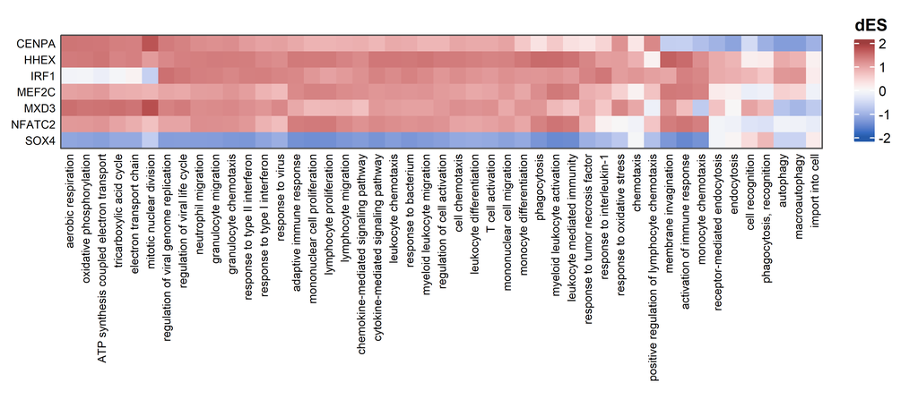

Example of Heatmap for Regulons vs GO terms

```r
# Retrieving GO term annotations using biomaRt
db_homo_s <- useMart(biomart = 'ENSEMBL_MART_ENSEMBL', dataset = 'hsapiens_gene_ensembl')

genes_go_id <- getBM(attributes = c('ensembl_gene_id', 'hgnc_symbol', 'go_id', 'name_1006', 'namespace_1003'),
                     filters = 'ensembl_gene_id', values = gene_annot$ENSEMBL,
                     mart = db_homo_s, uniqueRows = F, useCache = T)

genes_go_id <- subset(genes_go_id, genes_go_id$namespace_1003 == 'biological_process')

go_ids <- unique(c('GO:0009615', 'GO:0034341', 'GO:0019221', 'GO:0008037',
                   'GO:0002521', 'GO:0071621', 'GO:0002250', 'GO:0034612',
                   'GO:0097530', 'GO:0140546', 'GO:0140131', 'GO:0042110',
                   'GO:0016236', 'GO:1990266', 'GO:0045069', 'GO:1903900',
                   'GO:0009617', 'GO:0030595', 'GO:0072676', 'GO:1990868',
                   'GO:0030224', 'GO:0006914', 'GO:0070555', 'GO:0060326',
                   'GO:0070098', 'GO:0097529', 'GO:0006897', 'GO:0098657',
                   'GO:0002274', 'GO:0002443', 'GO:0006935', 'GO:0002548',
                   'GO:0006910', 'GO:0034340', 'GO:0006898', 'GO:0010324',
                   'GO:0031349', 'GO:0140014', 'GO:0009060', 'GO:1990266',
                   'GO:0071621', 'GO:0006119', 'GO:0097530', 'GO:0022900',
                   'GO:0002521', 'GO:0006099', 'GO:0050865', 'GO:0071674',
                   'GO:0006909', 'GO:0006979', 'GO:0046651', 'GO:0032943',
                   'GO:0060326', 'GO:0006898', 'GO:0002253', 'GO:0042773'))

go_terms_human <- mapIds(org.Hs.eg.db, keytype = 'GOALL', keys(org.Hs.eg.db, 'GO'), column = 'SYMBOL', multiVals = 'list')
go_terms_human <- enframe(go_terms_human)
go_terms_human <- subset(go_terms_human, go_terms_human$name %in% go_ids)

go_terms_human <- left_join(go_terms_human, genes_go_id[,c(3,4)], by = join_by('name' == 'go_id'),
                            multiple = 'first') %>% relocate(name_1006, .after = name)

go_terms_human <- go_terms_human[2:3]
colnames(go_terms_human) <- c('go_description', 'genes')

# Creating enriched_gene_set function to run GSEA-like enrichment analysis
# on selected regulons

enriched_gene_set <- function(cluster, regulons){
  cluster <- cluster
  cluster <- deframe(cluster)

  enriching_sets <- tni.annotate.regulons(microglia_tni, cluster, regulatoryElements = regulons,
                                            minSetSize = 15, sizeFilterMethod = 'posORneg')

  return(enriching_sets)
}

regulons_vs_go_terms <- enriched_gene_set(go_terms_human, sort(c('IRF1', 'CENPA', 'MXD3', 'HHEX', 'SOX4', 'MEF2C', 'NFATC2')))

# Preparing data to be displayed as heatmap

heatmap2regulons_go_terms <- Heatmap(regulons_vs_go_terms, col = colorRamp2(seq(-2.5,2.5,0.1), hcl_palette = 'Blue-Red 3', reverse = F), border = 'grey30',
                                     name = 'dES', row_names_centered = F,
                                     column_names_side = 'bottom', column_names_centered = F, cluster_rows = F, cluster_columns = T,
                                     show_column_dend = F, show_row_dend = F, row_names_side = 'left', row_gap = unit(2, 'mm'), column_gap = unit(2, 'mm'),
                                     show_column_names = T, column_title = NULL, row_title = NULL,
                                     row_names_gp = gpar(col = 'black', fontfamily = 'sans', fontsize = 6),
                                     width = ncol(regulons_vs_go_terms) * unit(3, 'mm'), height = nrow(regulons_vs_go_terms) * unit(3, 'mm'),
                                     column_names_gp = gpar(col = 'black', fontfamily = 'sans', fontsize = 6),
                                     heatmap_legend_param = list(grid_height = unit(8, 'mm'), grid_width = unit(4, 'mm'), labels_gp = gpar(family = 'sans', fontsize = 8),
                                                                 title_gp = gpar(fontfamily = 'sans', fontsize = 10, fontface = 'bold'), at = seq(-2,2,1),
                                                                 title_position = 'topleft'))

tiff('Heatmap Overlap GO BP and Regulons.tiff', units = 'mm', res = 600, width = 164, height = 70, compression = 'lzw')

heatmap2regulons_go_terms

dev.off()
```